[figure not shown]

## JHPL Leader Board Update

Hello JHPL members. This is your update for all things JHPL as of 2025-01-19.

First of all, thank you for playing JHPL. We had a great kickoff to the 2025 season. Congratulations to the winners. In the table below, many of the games statistics of interest are displayed. Of particular interest is the Total Points and the Top 10 Points. The total points represent the total points accumulated from all tournaments played this year and will be used to determine each players starting stack size in the final legacy tournament. The top ten points will be used to determine the overall season winner and the winner(s) of the points pool. All statistics are sortable.

Here are our current leaders:

|  | Name | Player | Games Played | Cashes | Bubble | KOs | Top 10 Points | Points |
| --- | --- | --- | --- | --- | --- | --- | --- | --- |
| 1 | Cameron Boyd | AdHominem | 1 | 1 | 0 | 5 | 35.33 | 35.33 |
| 2 | Bryce Cruey | Cru1 | 1 | 1 | 0 | 1 | 26.45 | 26.45 |
| 3 | Jerry Hanson | Jerry_av | 1 | 1 | 0 | 2 | 19.76 | 19.76 |
| 4 | Adam Hendrickson | Hendo | 1 | 0 | 0 | 0 | 13.57 | 13.57 |
| 5 | Mik Motzko | maps8452 | 1 | 0 | 1 | 0 | 12.78 | 12.78 |
| 6 | Dennis Koeller | dkoe | 1 | 0 | 0 | 0 | 12.38 | 12.38 |
| 7 | Chris Boyd | ALLAMERICAN | 1 | 0 | 0 | 3 | 11.46 | 11.46 |
| 8 | Kurt T | tootyttotoot | 1 | 0 | 0 | 0 | 10.72 | 10.72 |
| 9 | Matt Ezrol | Bigace223 | 1 | 0 | 0 | 0 | 9.59 | 9.59 |
| 10 | Erik Erdell | VegEEburgher | 1 | 0 | 0 | 0 | 9.15 | 9.15 |

[output cut: 1 more lines]

## Cashes

|  | Name | Player | Paid | Bounties Won | Tournament Winnings | ITM | ROI |
| --- | --- | --- | --- | --- | --- | --- | --- |
| 1 | Cameron Boyd | AdHominem | 50 | 0 | 280 | 1 | 4.6 |
| 2 | Bryce Cruey | Cru1 | 50 | 0 | 168 | 1 | 2.36 |
| 3 | Jerry Hanson | Jerry_av | 100 | 0 | 112 | 1 | 0.12 |
| 4 | Adam Hendrickson | Hendo | 50 | 0 | 0 | 0 | -1 |
| 5 | Mik Motzko | maps8452 | 100 | 0 | 0 | 0 | -1 |
| 6 | Dennis Koeller | dkoe | 50 | 0 | 0 | 0 | -1 |
| 7 | Chris Boyd | ALLAMERICAN | 50 | 0 | 0 | 0 | -1 |
| 8 | Kurt T | tootyttotoot | 50 | 0 | 0 | 0 | -1 |
| 9 | Matt Ezrol | Bigace223 | 50 | 0 | 0 | 0 | -1 |
| 10 | Erik Erdell | VegEEburgher | 50 | 0 | 0 | 0 | -1 |

[output cut: 1 more lines]

## Upcomming Events

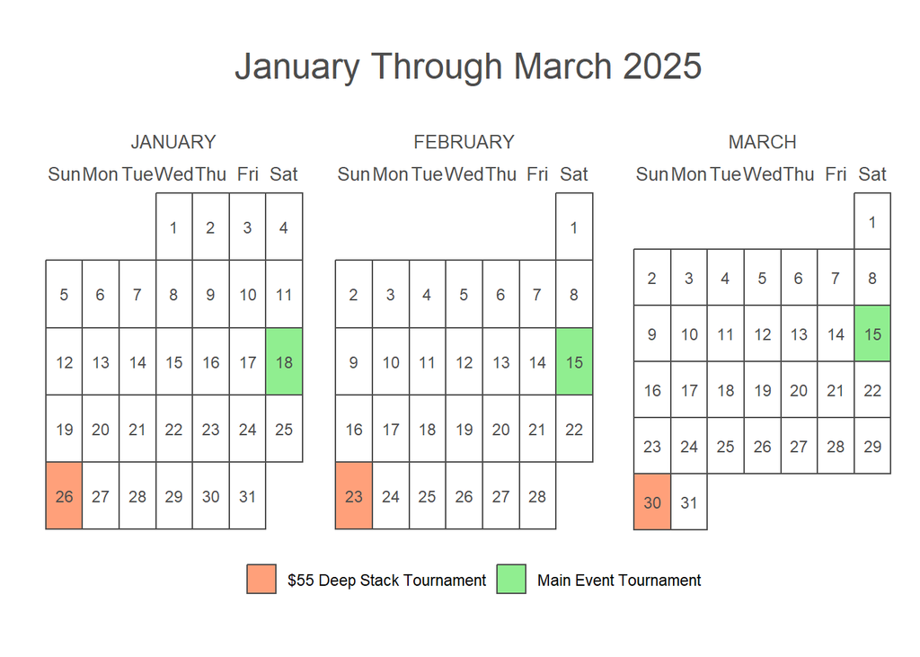